# Statistical Summaries

### What is the duration of monitoring?

The functions `min()`, `max()` and `range()` are self-explanatory, but importantly work excellenty with properly formatted time objects.

The `diff()` function calculates differences among subsequent elements of a vector. But for time (POSIX) data, it is best to use the `difftime(t1, t2)` function, since that allows you to specify the units of the time difference (hours, days, etc.) Otherwise, strange things can happen.

For example, the overall time span of the monitoring effort for the individual “GP1” one is:

```r
GP1 <- subset(elk_df, id =="GP1")

range(diff(GP1$datetime))
```

```
## Time differences in hours
## [1] 1.966667 4.000000
```

The units returned (hours) is not helpful.

But `difftime` is a bit more useful:

```r
difftime(max(GP1$datetime), min(GP1$datetime), units = "days")
```

```
## Time difference of 4.249306 days
```

This individual has a pretty short track!

We can also look at the time range of the entire dataset:

```r
difftime(max(elk_df$datetime), min(elk_df$datetime), units = "days")
```

```
## Time difference of 1166.624 days
```

Days is not as helpful as years.

Years is not an option with `difftime`, but to manipulate the output statistically, you need to convert to numeric. Thus the number of years for the entire dataset is:

```r
(difftime(max(elk_df$datetime), min(elk_df$datetime), units = "days") |> as.numeric())/365.25
```

```
## [1] 3.194043
```

~ 3 years (not bad!)

What we really want is to figure this out for each individual, all at once. One approach is to use the `plyr::ddply` command. This function allows you to apply functions to different groups (subsets) of a data set. Here’s an example:

```r
elk_df |> ddply("id", plyr::summarize,
                 start= min(datetime), end = max(datetime)) %>%
  mutate(duration = difftime(end, start, units = "days"))
```

| id | start | end | duration |
| --- | --- | --- | --- |
| 4049 | 2001-12-13 07:01:00 | 2002-11-14 03:00:00 | 335.832639 days |
| GP1 | 2003-03-25 19:01:00 | 2003-03-30 01:00:00 | 4.249306 days |
| GP2 | 2003-03-15 01:00:00 | 2004-01-04 09:01:00 | 295.334028 days |
| GR104 | 2004-03-29 19:00:00 | 2005-01-22 15:00:00 | 298.833333 days |
| GR182 | 2002-04-05 07:01:00 | 2002-12-17 17:00:00 | 256.415972 days |
| GR193 | 2002-04-05 23:01:00 | 2002-11-23 15:01:00 | 231.666667 days |

The (near) equivalent with `dplyr` commands, but just for duration:

```r
elk_df |> group_by(id) |>
  dplyr::summarize(duration = difftime(max(datetime), min(datetime), units = "days"))
```

```
## # A tibble: 31 × 2
##    id    duration
##    <fct> <drtn>
##  1 4049  335.832639 days
##  2 GP1     4.249306 days
##  3 GP2   295.334028 days
##  4 GR104 298.833333 days
##  5 GR182 256.415972 days
##  6 GR193 231.666667 days
##  7 GR196  70.395833 days
##  8 YL15  323.667361 days
##  9 YL2   334.584722 days
## 10 YL25  388.537500 days
## # ℹ 21 more rows
```

To get statistical summaries of these durations, you have to convert the time range object (which is a unique `difftime` class) into numeric. Thus:

```r
elk_summary <- elk_df |> group_by(id) |>
  dplyr::summarize(time_range = difftime(max(datetime), min(datetime), units ="days"))

elk_summary$time_range |> as.numeric() |> summary()
```

```
##    Min. 1st Qu.  Median    Mean 3rd Qu.    Max.
##   4.249 170.677 269.000 231.236 308.727 388.538
```

We can visualize the monitoring duration for each individual, on a plot, by extracting the start date and the end date of the monitoring for each individual.

```r
n.summary <- elk_df |> group_by(id) |>
  summarize(start = min(datetime), end = max(datetime))
```

Here’s a version using `ggplot2`

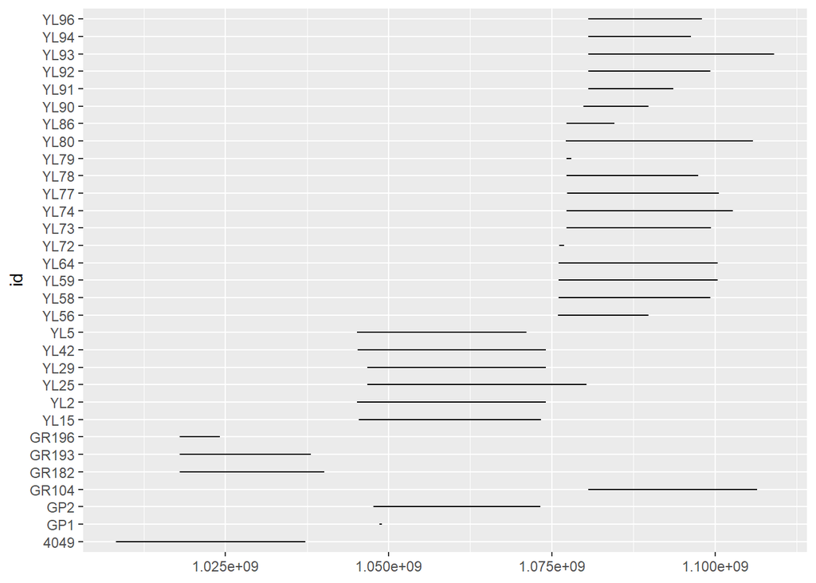

```r
require(ggplot2)
ggplot(n.summary, aes(y = id, xmin = start, xmax = end)) +
    geom_linerange()
```

It may make more sense to sort the individuals not alphabetically, but by the time of release. Here’s an approach, which relies on reordering the factor levels of the id column (an often fussy task):

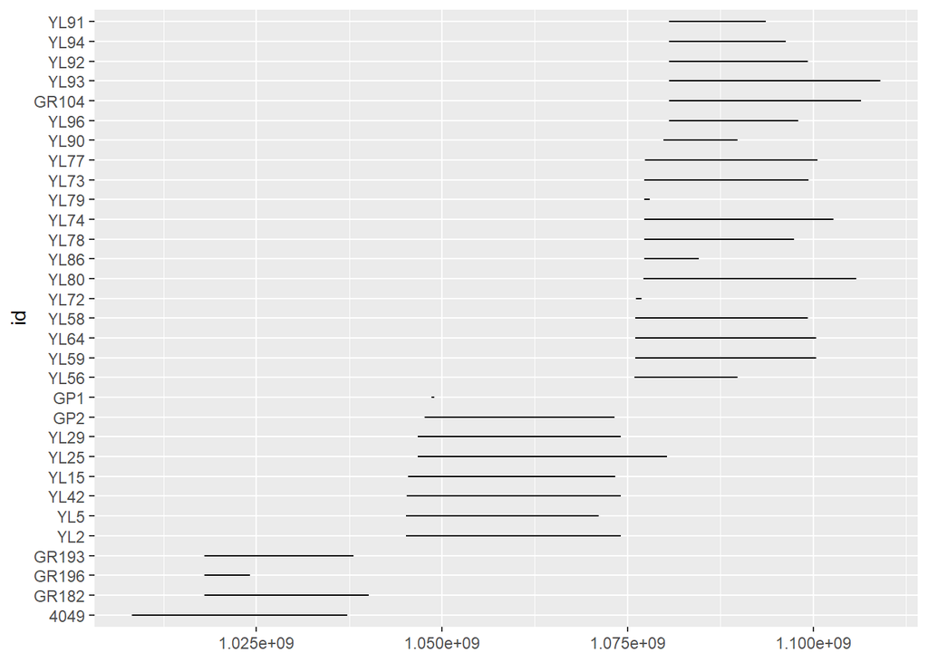

```r
n.summary <- elk_df |> group_by(id) |>
  summarize(start = min(datetime), end = max(datetime)) %>%
  arrange(start) |>
  mutate(id = factor(id, levels = as.character(id)))

ggplot(n.summary, aes(y = id, xmin = start, xmax = end)) +
    geom_linerange()
```

This is quick and easy and attractive enough. But, for the record, if you wanted to use base plotting functions (which, for many applications, can be much more easy to customize), code for a similar plot would look something like this:

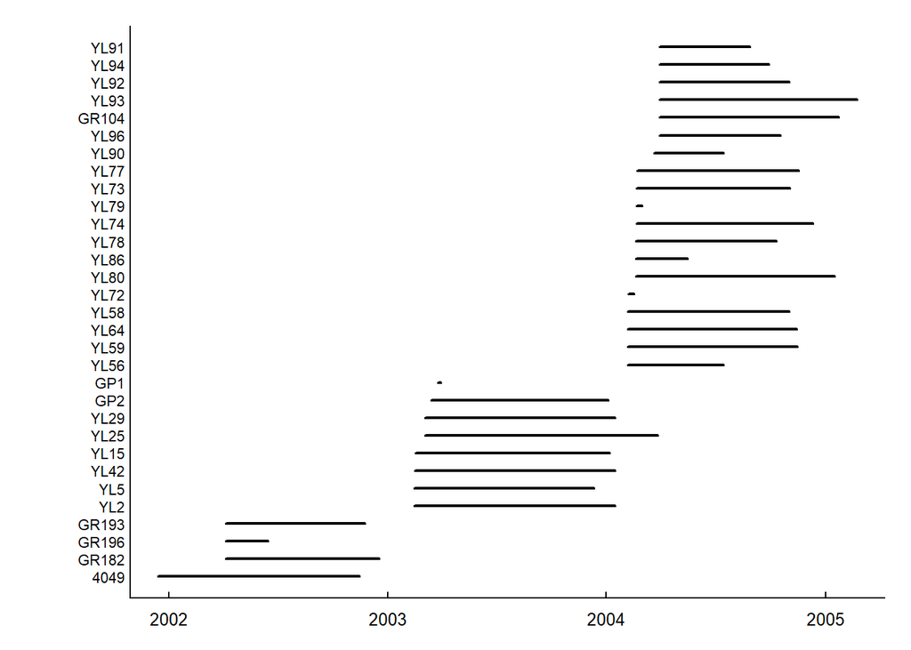

```r
with(n.summary, {
  plot(start, id, xlim = range(start, end),
       type = "n", yaxt = "n", ylab = "", xlab = "")
  segments(start, as.integer(id), end, as.integer(id), lwd = 2)
  mtext(side = 2, at = 1:nrow(n.summary), id, cex = 0.7, las = 1, line = .2)
  })
```

In any case, on this figure each line represents the duration of the monitoring (x axis) for a given individual (y axis). While we see the beginning and end of the monitoring for each individual, we cannot see if there are any gaps in the monitoring.

To see if there is one or multiple gaps, we can create a vector of Date for each individual (i.e., containing only the date and not the time, to simplify the it and get only get one row per day per individual). To get the date from a time vector, we use the `as.Date` function. We then use the `slice()` command to keep only row per day for each individual. Do not forget to arrange per ID and date as all these manipulation can sometimes mess up the ordering of your data.

```r
elk_days <- elk_df |> mutate(date = as.Date(datetime)) |>
  group_by(id, date) |>
  slice(1) |> arrange(id, datetime)
```

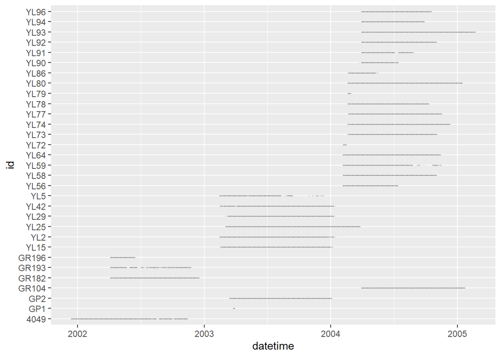

```r
ggplot(elk_days, aes(y = id, x = datetime)) +
    geom_point(shape = 20, size = .5, alpha = .1)
```

Similar to the previous figure, each line represent the monitoring dates for a given individual. But from this figure, we can see that there are some gaps in the monitoring of some individuals.

### What is the fix rate?

The fix rate, or the time lag between successive locations, can be extracted by using the `difftime()` function on the `Time` column. Again, this function needs to be applied to each individual separately. Here, we are subsetting the data set per ID, and applying a function which is adding a column *difftime* to each subset. Note that since the vector of time difference is smaller than the vector of time, we add a missing value at the beginning of each vector, for each value to represent the difference in time to the previous location.

```r
elk_df <- elk_df |> ddply("id", mutate,
        dtime = c(NA, difftime(datetime[-1], datetime[-length(datetime)], units = "hours")))
```

[output not shown]

What are the statistics (min, max, mean, median, …) of this fix rate?

```r
elk_df$dtime |> summary()
```

```
## Length  Class   Mode
##      0   NULL   NULL
```

## More Data Processing

The previous section illustrated a few typical approaches to *exploring* a movement dataset. *Processing* the data - broadly speaking - implies that we will be organizing it, filtering it, or adding information to the data frame in ways that contributes in a meaningful way to some key research question. By that definition, for example, the inclusion of the individual specific fix rate above is a key bit of *data processing*.

As an example, we might investigate the following question: *Is there a difference in the movement rates between winter and summer, for elk?*

### Subsetting by Season

```r
elk_winter_summer <- elk_df |> mutate(Month = month(datetime)) |>
  subset(Month %in% c(1,2,6,7))

str(elk_winter_summer)
```

```
## 'data.frame':    44865 obs. of  9 variables:
##  $ datetime: POSIXct, format: "2002-01-01 01:00:00" "2002-01-01 03:01:00" ...
##  $ lon     : num  -116 -116 -116 -116 -116 ...
##  $ lat     : num  52.1 52.1 52.1 52.1 52.1 ...
##  $ id      : Factor w/ 31 levels "4049","GP1","GP2",..: 1 1 1 1 1 1 1 1 1 1 ...
##  $ X       : num  582102 582139 582433 582433 582295 ...
##  $ Y       : num  5773067 5773065 5773290 5773293 5772883 ...
##  $ doy     : num  1 1 1 1 1 1 1 1 1 1 ...
##  $ Month   : num  1 1 1 1 1 1 1 1 1 1 ...
##  $ Year    : num  2002 2002 2002 2002 2002 ...
```

To add a column “season”, we can use the `ifelse()`, function which returns different values depending on whether a given element in a vector satisfies a condition.

```r
elk_winter_summer <- elk_winter_summer |>
  mutate(season = ifelse(Month < 3, "Winter", "Summer"))

table(elk_winter_summer$season)
```

```
##
## Summer Winter
##  36546   8319
```

You could also perform this operation with a vector of days of year and the useful `cut()` function, which transforms numeric data to ordered factors. Thus, to obtain breaks:

```r
season.dates <- c(winter.start = yday("2023-01-01"),
                  winter.end = yday("2023-02-28"),
                  summer.start = yday("2023-07-01"),
                  summer.end = yday("2023-08-31"))
season.dates
```

```
## winter.start   winter.end summer.start   summer.end
##            1           59          182          243
```

```r
cut.dates <- c(season.dates, 367)

elk_winter_summer <- elk_df |>
  mutate(season = cut(yday(datetime), cut.dates, labels = c("winter","other","summer","other"))) |>
  subset(season != "other") |> droplevels()

table(elk_winter_summer$season)
```

```
##
## winter summer
##   7908  30415
```

### Estimating the Movement Rate

To estimate the movement rate between subsequent steps for each individual and each season, we will use what we learned in our lab on Complex Numbers.

1. Create a Z vector combining the X and Y coordinates
2. Calculate the step lengths (SL)
3. Calculate the time difference of the steps
4. Calculate step’s movement rate

As we need to do this for each individual, year and season separately, we will use the `ddply()`, as before. Note, that to do this most effectively, it is nice to write our own function that makes all the computations we need. The key in this function is that the movement rate (MR) is the step length divided by the time difference, converted ti km/hour. Here’s one such function:

```r
getMoveStats <- function(df){
  # df - is a generic data frame that will contain X,Y and Time columns
  Z <- df$X + 1i*df$Y
  Time <- df$datetime
  Step <- c(NA, diff(Z)) # we add the extra NA because there is no step to the first location
  dT <- c(NA, difftime(Time[-1], Time[-length(Time)], hours) |> as.numeric())

  SL <- Mod(Step)/1e3 # convert to km - so the speed is in km/hour
  MR <- SL/dT # computing the movement rate

  # this is what the function returns
  data.frame(df, Z, dT, Step, SL, MR)
}
```

We took care to pick this function apart into individual pieces. And understand that it returns a new data frame with the additional columns appended to the original data frame. THe `ddply` command will apply this function to every individual in every season in every year. This is now very quick:

```r
elk_winter_summer <- elk_winter_summer |>
  plyr::ddply(c("id", "Year", "season"), getMoveStats)
```

| datetime | lon | lat | id | X | Y | doy | Month | Year | season | Z | dT | Step | SL | MR |
| --- | --- | --- | --- | --- | --- | --- | --- | --- | --- | --- | --- | --- | --- | --- |
| 2002-01-02 01:01:00 | -115.8005 | 52.10077 | 4049 | 582158.5 | 5772925 | 2 | 1 | 2002 | winter | 582158+5772925i | NA | NA | NaN | NaN |
| 2002-01-02 03:01:00 | -115.8005 | 52.10071 | 4049 | 582161.3 | 5772918 | 2 | 1 | 2002 | winter | 582161+5772918i | 2.000000 | 2.849962-6.627862i | 0.0072146 | 0.0036073 |
| 2002-01-02 05:01:00 | -115.8027 | 52.09858 | 4049 | 582012.5 | 5772679 | 2 | 1 | 2002 | winter | 582012+5772679i | 2.000000 | -148.831983-239.417329i | 0.2819071 | 0.1409536 |
| 2002-01-02 07:00:00 | -115.8025 | 52.10186 | 4049 | 582022.9 | 5773044 | 2 | 1 | 2002 | winter | 582023+5773044i | 1.983333 | 10.421707+365.068825i | 0.3652175 | 0.1841433 |
| 2002-01-02 09:00:00 | -115.8024 | 52.10193 | 4049 | 582027.6 | 5773052 | 2 | 1 | 2002 | winter | 582028+5773052i | 2.000000 | 4.665938+7.864406i | 0.0091444 | 0.0045722 |
| 2002-01-02 11:00:00 | -115.8075 | 52.10381 | 4049 | 581673.5 | 5773255 | 2 | 1 | 2002 | winter | 581673+5773255i | 2.000000 | -354.107794+203.319095i | 0.4083271 | 0.2041635 |

### Quick analysis of Movement Rates

We are ready now (finally) to answer the question: **Is there a difference in movement rate between winter and summer?** We can start with a quick boxplot of the movement rates against individual ID’s and season. The distributions are highly skewed and quite variable, with some animals really on the move, and some spending a lot of time not moving at all.

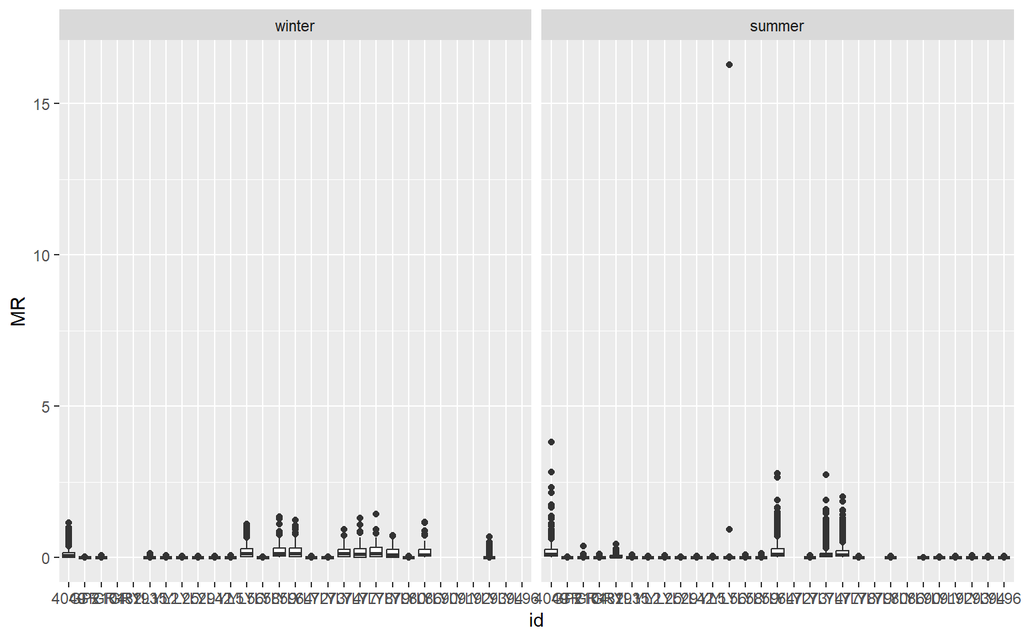

```r
ggplot(elk_winter_summer, aes(id, MR)) +
  geom_boxplot() +
  facet_wrap(.~season)
```

Some season & individual summary stats:

```r
mr_summarystats <- elk_winter_summer |>
  ddply(c("id","season"), summarize,
  min = min(MR, na.rm = TRUE), max = max(MR, na.rm = TRUE),
  n = length(MR), NA.count = sum(is.na(MR)),
  Zero.count = sum(MR == 0, na.rm = TRUE))
```

| id | season | min | max | n | NA.count | Zero.count |
| --- | --- | --- | --- | --- | --- | --- |
| 4049 | winter | 0.0005562 | 1.1591620 | 630 | 1 | 0 |
| 4049 | summer | 0.0000000 | 3.8232244 | 468 | 1 | 1 |
| GP2 | winter | 0.0000482 | 0.0322507 | 113 | 1 | 0 |
| GP2 | summer | 0.0000091 | 0.0416813 | 1137 | 1 | 0 |
| GR104 | winter | 0.0000000 | 0.0826776 | 997 | 1 | 1 |
| GR104 | summer | 0.0000000 | 0.3857443 | 3022 | 1 | 5 |
| GR182 | summer | 0.0000000 | 0.1277045 | 1776 | 1 | 3 |
| GR193 | summer | 0.0020907 | 0.4542548 | 95 | 1 | 0 |
| YL15 | winter | 0.0000000 | 0.1401184 | 212 | 2 | 1 |
| YL15 | summer | 0.0000115 | 0.0948403 | 956 | 1 | 0 |
| YL2 | winter | 0.0000109 | 0.0740076 | 413 | 2 | 0 |
| YL2 | summer | 0.0000115 | 0.0461451 | 866 | 1 | 0 |
| YL25 | winter | 0.0000148 | 0.0604432 | 756 | 1 | 0 |
| YL25 | summer | 0.0000148 | 0.0771532 | 900 | 1 | 0 |
| YL29 | winter | 0.0000000 | 0.0470449 | 191 | 1 | 1 |
| YL29 | summer | 0.0000247 | 0.0384856 | 904 | 1 | 0 |
| YL42 | winter | 0.0000002 | 0.0449675 | 355 | 2 | 0 |
| YL42 | summer | 0.0000249 | 0.0586047 | 845 | 1 | 0 |
| YL5 | winter | 0.0000058 | 0.0761048 | 251 | 1 | 0 |
| YL5 | summer | 0.0000193 | 0.0470756 | 515 | 1 | 0 |
| YL56 | winter | 0.0008793 | 1.1136503 | 276 | 1 | 0 |
| YL56 | summer | 0.0001638 | 16.2704332 | 122 | 1 | 0 |
| YL58 | winter | 0.0000115 | 0.0314292 | 510 | 1 | 0 |
| YL58 | summer | 0.0000000 | 0.1017277 | 2281 | 1 | 2 |
| YL59 | winter | 0.0006546 | 1.3548113 | 272 | 1 | 0 |
| YL59 | summer | 0.0000000 | 0.1446085 | 1754 | 1 | 4 |
| YL64 | winter | 0.0003453 | 1.2327423 | 276 | 1 | 0 |
| YL64 | summer | 0.0000000 | 2.7805448 | 646 | 1 | 1 |
| YL72 | winter | 0.0000185 | 0.0441269 | 167 | 1 | 0 |
| YL73 | winter | 0.0000115 | 0.0343486 | 216 | 1 | 0 |
| YL73 | summer | 0.0000000 | 0.0744825 | 3004 | 1 | 2 |
| YL74 | winter | 0.0006905 | 0.9298874 | 109 | 1 | 0 |
| YL74 | summer | 0.0003498 | 2.7374940 | 641 | 1 | 0 |
| YL77 | winter | 0.0008866 | 1.3120573 | 90 | 1 | 0 |
| YL77 | summer | 0.0011643 | 2.0130848 | 622 | 1 | 0 |
| YL78 | winter | 0.0005562 | 1.4374815 | 111 | 1 | 0 |
| YL78 | summer | 0.0000174 | 0.0649781 | 1109 | 1 | 0 |
| YL79 | winter | 0.0000000 | 0.7382906 | 108 | 1 | 1 |
| YL80 | winter | 0.0000000 | 0.0443451 | 534 | 2 | 1 |
| YL80 | summer | 0.0000000 | 0.0608402 | 1140 | 1 | 1 |
| YL86 | winter | 0.0006546 | 1.1694095 | 56 | 1 | 0 |
| YL90 | summer | 0.0000075 | 0.0048971 | 142 | 1 | 0 |
| YL91 | summer | 0.0000185 | 0.0344171 | 658 | 1 | 0 |
| YL92 | summer | 0.0000116 | 0.0541312 | 1382 | 1 | 0 |
| YL93 | winter | 0.0000000 | 0.6984110 | 1265 | 1 | 5 |
| YL93 | summer | 0.0000000 | 0.0871846 | 2687 | 1 | 13 |
| YL94 | summer | 0.0000000 | 0.0610999 | 1330 | 1 | 1 |
| YL96 | summer | 0.0000000 | 0.0588989 | 1413 | 1 | 2 |

Our output helpfully shows the number of NA’s and zeros for each individual and by the season. Individuals with many 0’s or NA’s may warrant further investigation or even dropping from your dataset.